# ADP3

# 1 Preparations (준비작업)

## 1.1 Libraries

```r
library(data.table)
library(tidyverse)
library(forecast)

theme_set(theme_bw())
```

# 2 시계열 모형 소개

## 2.1 시계열 모형 종류

- AR
- MA
- ARMA
- ARIMA
- SARIMA
- Time series regression

**기출문제 확인 결과 ARIMA, SARIMA, Time series regression이 나옴**.

**데이터는 시계열 예제 데이터 수준이므로 분석 프로세스만 숙지하고 있으면 됨**

## 2.2 시계열 기본 가정

**백색잡음과정**

서로 독립이고 동일한 분포를 따르는(i.i.d) 확률변수로 구성된 확률과정

- 뚜렷한 추세가 없음
- 시계열의 진폭이 일정함

**이 형태 혹은 비슷한 형태를 띄어야 정상 시계열로 인식함**

**기본 가정이라고 생각하면 되고, 정상 시계열 형태가 아닐 경우 변환을 통해 정상 시계열로 만들어줘야함**

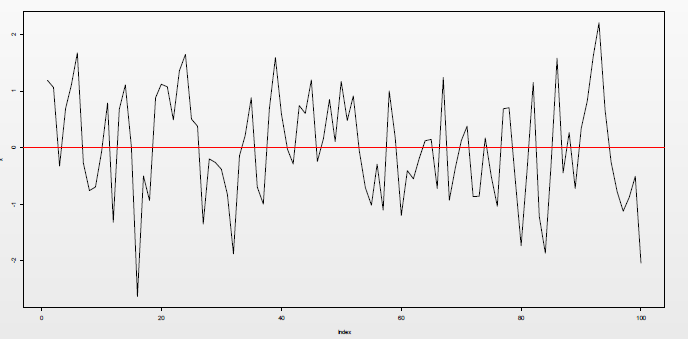

**확률보행과정**

평균은 일정하지만 분산과 자기공분산은 t 시점에 의존

- 뚜렷한 추세가 존재함
- 진폭이 불규칙적

**비정상 시계열의 대표적인 예시로 적절한 변환을 통해 정상 시계열로 만들어줘야함**

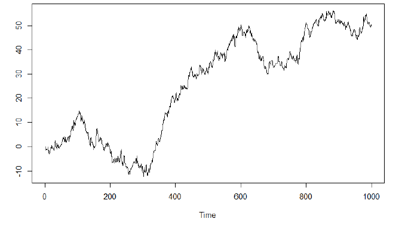

## 2.3 모형 인식 방법

**ACF(자기상관함수)**

시계열 자료 특성상 현재의 상태가 과거 및 미래의 상태와 연관되므로 시간에 따른 상관 정도를 측정하는 척도가 필요함

$$\rho_k = \frac{cov(Z_t, Z_t+k)}{\sqrt{var(Z_k)}\sqrt{var(Z_{t+k})}}$$

**Sample correlogram**(표본상관도표)

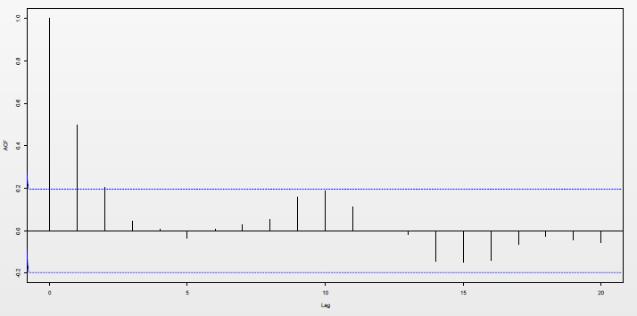

X축을 시차, Y축을 표본 ACF로 표현한 그림으로 모델 인식 절차에 사용됨.

- acf() 함수로 작성 가능
- $\rho_k = 0$이면 표본 ACF는 점근적으로 평균은 0, 분산은 $\frac{1}{n}$인 정규분포를 따르며, 이 성질에 따라 신뢰구간이 점선으로 추가됨
- 표본 ACF가 점선을 벗어나 있으면 $H_0 : \rho_k = 0$을 기각할 수 있음
- 각 시점에 대해 검정하므로 다중검정의 고질적 문제인 일종 오류가 증가하는 문제가 발생함
- 따라서 엄격한 검정 보다는 참고자료로 이용

**PACF(부분자기상관함수)**

$Z_t$와 $Z_{t+k}$ 사이의 직접적인 연관성을 측정하는 함수 $Z_t, Z_{t+1}, \cdots, Z_k$가 주어졌을 때 $Z_t$와 $Z_{t+k}$에서 $Z_{t+1}, \cdots, Z_{t+k-1}$의 효과를 제거한 후 상관관계를 측정함

**Sample partial correlogram(표본부분상관도표)**

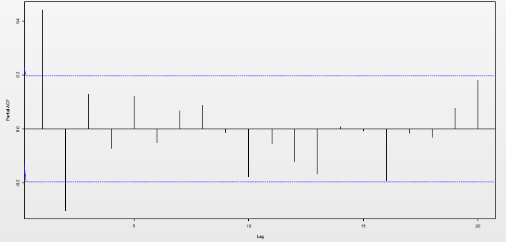

X축을 시차, Y축을 표본 PACF로 표현한 그림으로 모델 인식 절차에 사용됨.

- pacf() 함수로 작성 가능
- 문제점 ACF와 동일
- 따라서 엄격한 검정 보다는 참고자료로 이용

**ACF, PACF 그래프 이용해서 모형을 인식함. 따라서 그래프를 정확히 해석하는 것이 중요함**

# 3 AR 모형

## 3.1 AR(1)일 때

- ACF 지수적 감소
- PACF 1차 시점 이후 절단(1차 시점은 자기 자신이므로 상관관계는 1, 따라서 고려 X)

**이론적 그림이므로 비슷한 형태를 띄면 절단이라고 인식함. 그래프를 이용한 해석은 주관적이므로 정확한 정답은 없음. 다만 딱 봐도 절단이면 절단이라고 인식할 수 있어야 함**

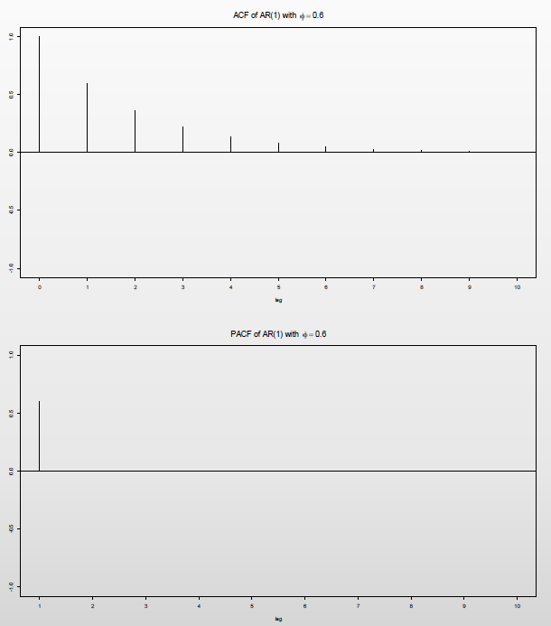

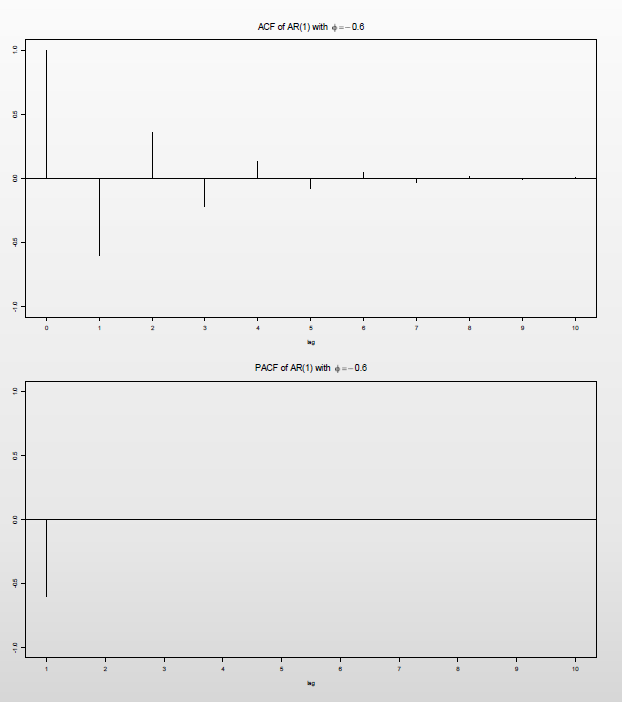

## 3.2 AR(2)일 때

- ACF 지수적 감소
- PACF 2차 시점 이후 절단

**AR(p) 차 시점 그림 또한 ACF 지수적 감소, PACF p차 시점 이후 절단으로 동일함**

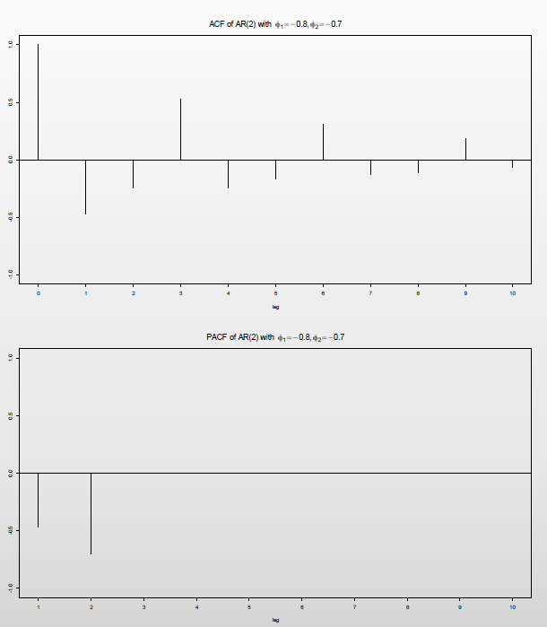

# 4 MA 모형

## 4.1 MA(1)일 때

- ACF 1차 시점 이후 절단
- PACF 지수적 감소

**AR모형과 ACF, PACF 그림만 반대이고, 모형 인식 방법은 동일함**

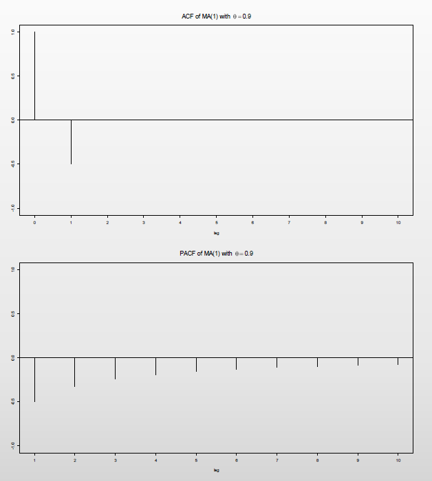

# 5 ARMA 모형

AR 모형과 MA모형을 합친 형태로, AR의 p와 MA의 q를 파라미터로 갖는 모형임

## 5.1 ARMA(1, 1)일 때

- ACF: AR(1)모형의 영향으로 지수적 감소
- PACF: MA(1)모형의 영향으로 지수적 감소

**그림을 추가하진 않았지만 AR, MA 모형의 지수적 감소 형태와 동일함**

# 6 AR, MA, ARMA 정리

| Model | ACF | PACF |
| --- | --- | --- |
| MA(q) | q 시차 이후 0으로 절단 | 지수적으로 감소 |
| AR(p) | 지수적으로 감소 | p시차 이후 0으로 절단 |
| ARMA(p, q) | 지수적으로 감소 | 지수적으로 감소 |

# 7 ARIMA

## 7.1 비정상 시계열 특징

- 추세가 존재
- 계절성 존재
- 분산이 시간대에 따라 변함

**실제 자료에서 정상성을 만족하는 경우는 거의 없으므로 변환을 통해 정상시계열로 만들어줘야함**

## 7.2 비정상 시계열 정상화 방법

**분산이 일정하지 않은 경우 : 분산안정화 변환 실시**

- 분산 증가 : 로그변환, 제곱근 변환
- 분산 감소 : 지수변환, 제곱 변환

**분산이 증가할 때**

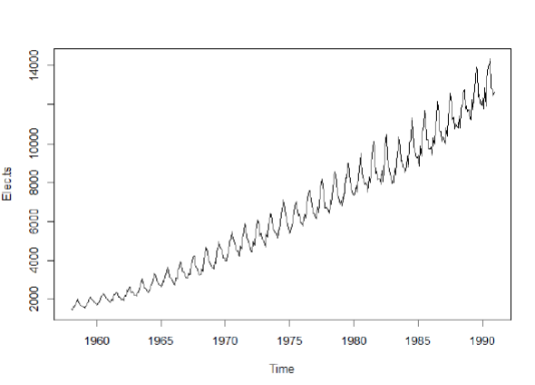

**분산안정화 변환 실시**

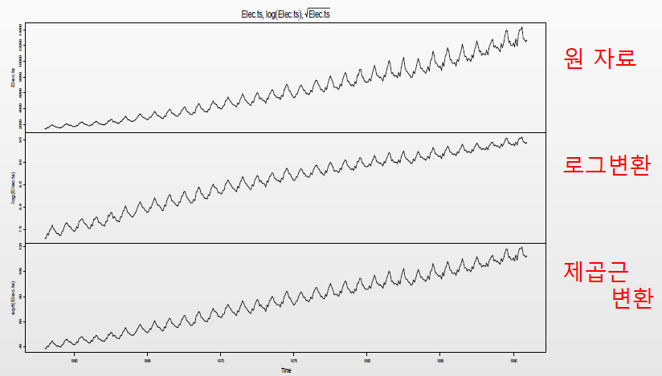

**추세가 존재하는 경우 : 차분 실시**

- 추세만 보고 명확하지 않을 수 있으므로, ACF 그래프도 같이 확인 필요
- 1차 차분으로 정상성을 만족하지 않을 경우 2차 차분까지 실시
- 3차 차분은 거의 하지 않으므로 고려 X
- 계절 효과가 존재하는 경우 계절형 차분 실시

**추세가 존재하는 경우**

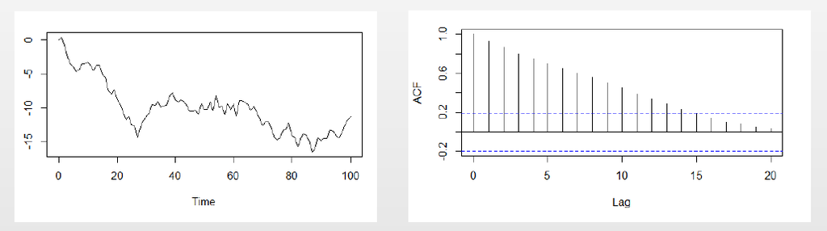

**1차 차분 실시**

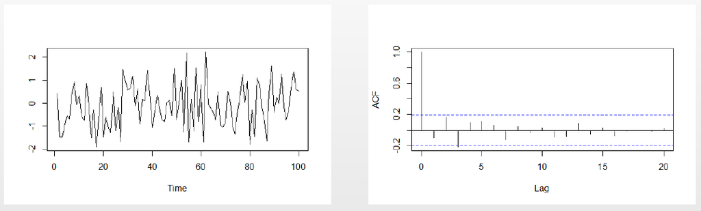

## 7.3 ARIMA(p, d, q)

ARMA 모형에 차분(d)이 추가된 모형임

- 추세가 있으면 차분 실시
- ACF가 천천히 감소하면 차분 실시
- 차분을 통해 정상시계열로 만들어준 후 차수 결정
- d차 차분된 자료의 ACF, PACF로 차수 결정(AR, MA, ARMA 차수 결정방법과 동일)
- ndiffs(x) : 일반 차분 차수 추정

## 7.4 Example

**데이터 생성** ARIMA(1, 1, 0)에서 난수 발생

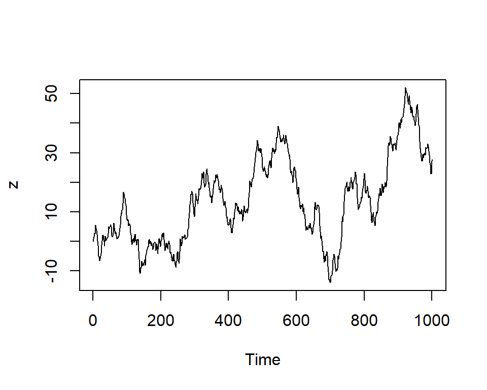

```r
set.seed(123)
z <- arima.sim(model = list(order = c(1, 1, 0), ar = 0.5), n = 1000)
plot(z)
```

**1차 차분**

ARIMA(1, 1, 0)으로 식별

```r
ndiffs(z)
```

```
## [1] 1
```

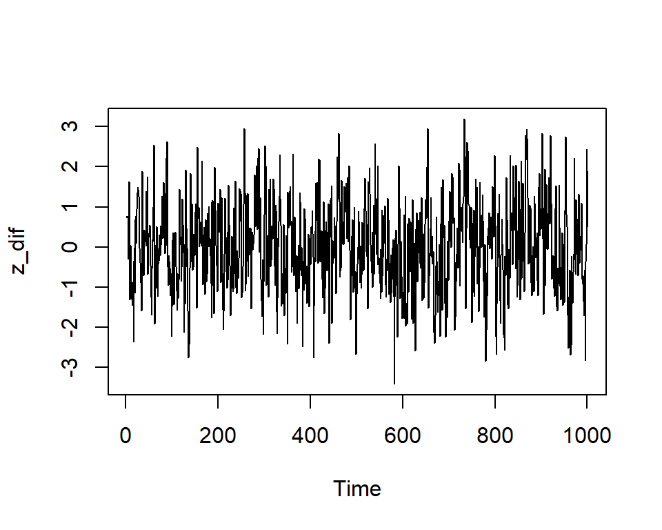

```r
z_dif <- diff(z)
plot(z_dif)
```

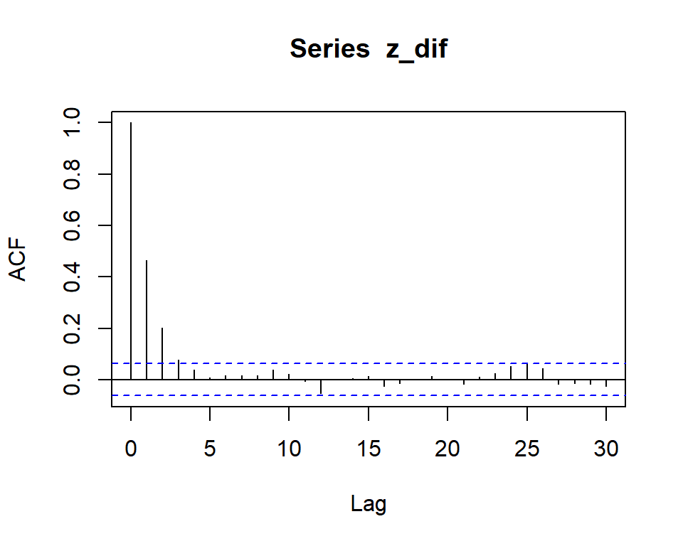

```r
acf(z_dif)
```

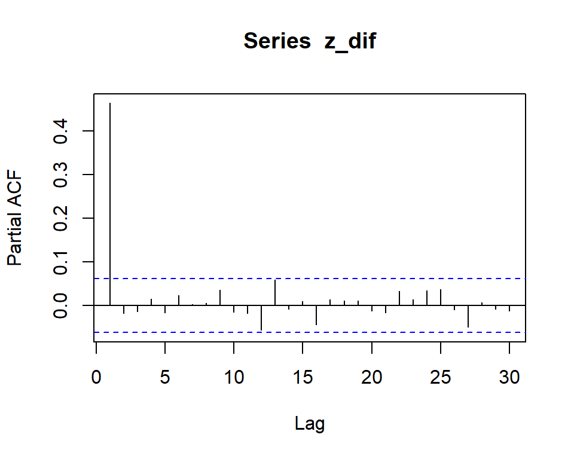

```r
pacf(z_dif)
```

**과대 차분했을 경우** 정상성은 만족하지만 AR(1)모형 보다는 더 복잡한 모형으로 인식함

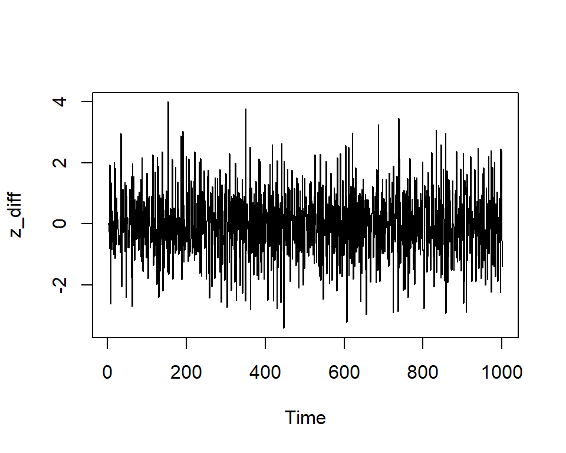

```r
z_diff <- diff(z, d = 2)
plot(z_diff)
```

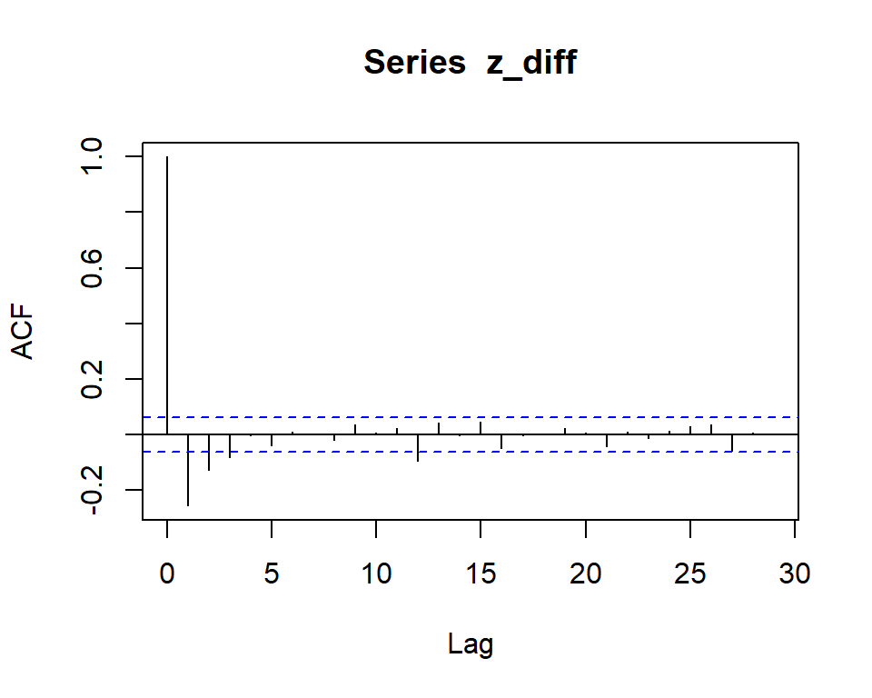

```r
acf(z_diff)
```

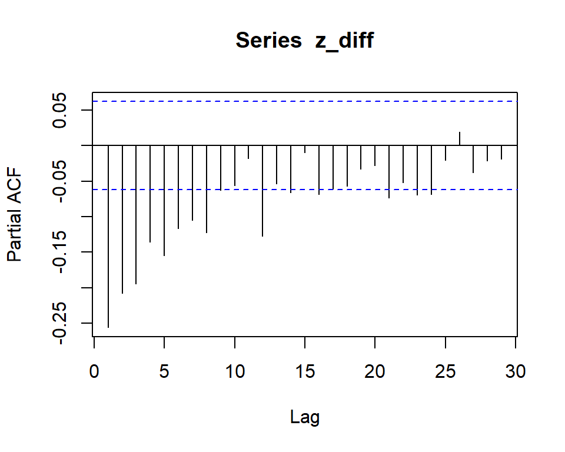

```r
pacf(z_diff)
```

# 8 SARIMA

ARIMA 모형에 계절 요소가 반영된 모형

- ARIMA모형과 마찬가지로 차수를 정할 때 ACF, PACF 그래프를 이용해서 확인
- 계절 요소도 ACF, PACF 그래프를 이용해서 확인

## 8.1 AR(1)_12 : ARIMA(0, 0, 0)(1, 0, 0)_12

- ACF : 계절 주기 12의 배수에 해당하는 시차 12, 24, 36, ..에 따라 지수적으로 감소
- PACF : 시차 12에서만 값을 갖고 그 외의 시차는 0으로 절단

## 8.2 MA(1)_12 : ARIMA(0, 0, 0)(0, 0, 1)_12

- ACF : 시차 12에서만 값을 갖고 그 외의 시차는 0으로 절단
- PACF : 계절 주기 12의 배수에 해당하는 시차 12, 24, 36, ..에 따라 지수적으로 감소

## 8.3 ARIMA_12: ARIMA(0, 0, 0)(1, 0, 1)_12

- ACF : 12 시차 이후부터 계절 주기 12 배수에 해당하는 시차에 따라 지수적 감소
- PACF : 12 시차 이후부터 계절 주기 12 배수에 해당하는 시차에 따라 지수적 감소

## 8.4 ARIMA(P, D, Q)_s

강한 계절요소로 인해 계절 추세가 존재하는 경우

- 계절 차분을 통해 정상성 회복
- nsdiffs(x, m = 계절 주기) : 계절 차분 차수 추정

## 8.5 ARIMA(p, d, q)(P, D, Q)_s

비계절형 ARIMA 요소, 계절형 ARIMA 요소를 모두 갖고 있는 모형

# 9 Time series regression

내용 추가

# 10 시계열 그래프 그리는 방법

내용 추가

# 11 Practice

# 12 ARIMA

## 12.1 추세 확인

비정상 시계열, 차분 필요

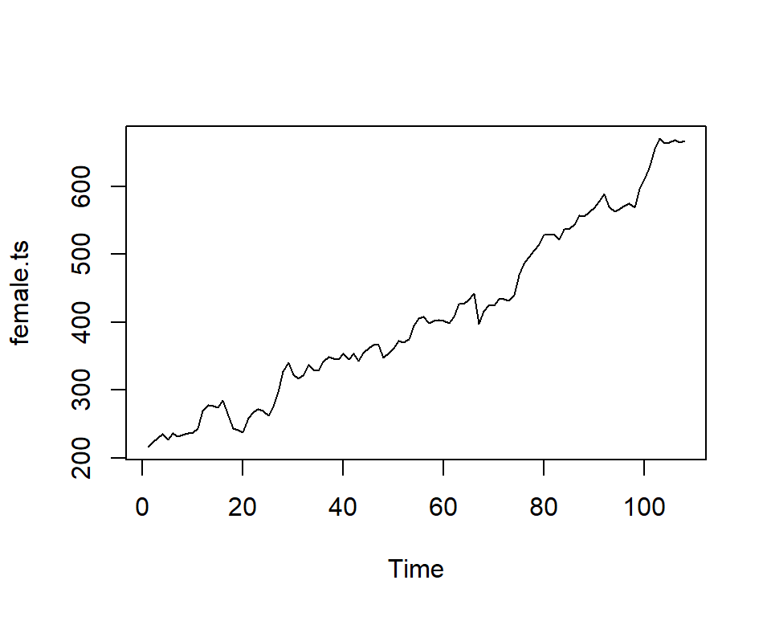

```r
library(forecast)
female <- scan('data/timeseries/female.txt')
female.ts <- ts(female)
plot(female.ts)
```

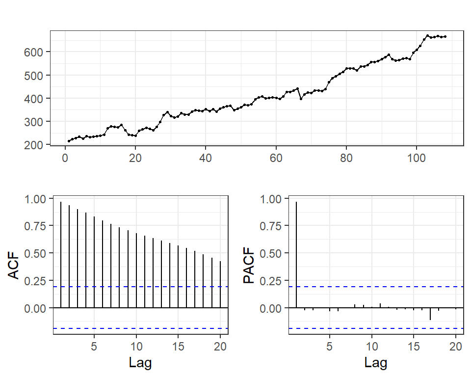

```r
ggtsdisplay(female.ts)
```

## 12.2 일반 차분

- white noise 만족
- p = 0, q = 0

```r
ndiffs(female)
```

```
## [1] 1
```

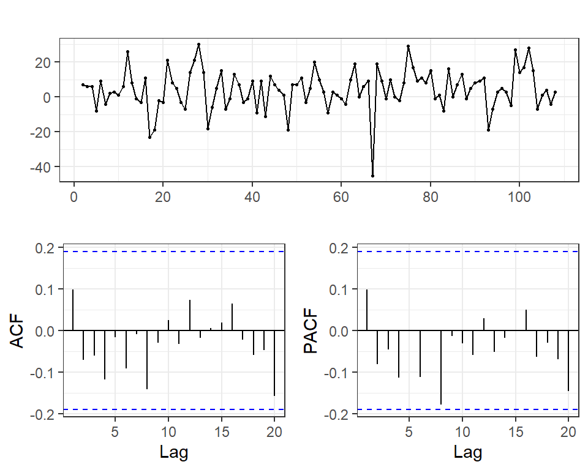

```r
female_d <- diff(female.ts)
ggtsdisplay(female_d)
```

## 12.3 Model fitting

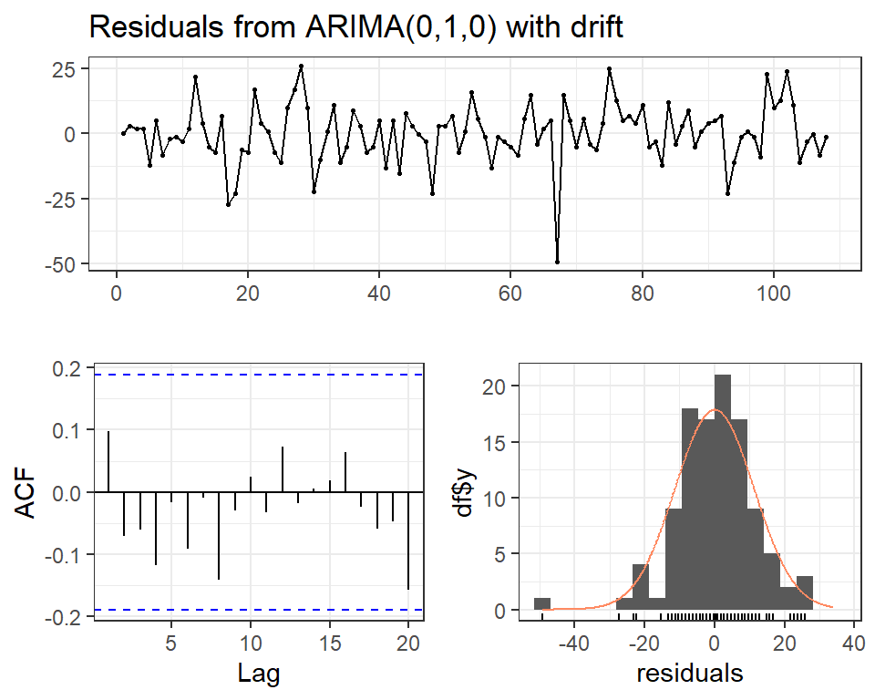

```
##
##  Ljung-Box test
##
## data:  Residuals from ARIMA(0,1,0) with drift
## Q* = 7.1676, df = 9, p-value = 0.6197
##
## Model df: 1.   Total lags used: 10
```

```r
fit <- Arima(female, order = c(0, 1, 0), include.drift = T)
checkresiduals(fit)
```

### 12.3.1 과대적합

```r
confint(Arima(female, order = c(1, 1, 0), include.drift = T)) # 추가된 모수 비유의
```

```
##             2.5 %    97.5 %
## ar1   -0.09026514 0.2851598
## drift  1.85683163 6.5762383
```

```r
confint(Arima(female, order = c(0, 1, 1), include.drift = T)) # 추가된 모수 비유의
```

```
##             2.5 %    97.5 %
## ma1   -0.08681113 0.3124909
## drift  1.84910777 6.5857555
```

```r
# ARIMA(0, 1, 0) 확정
```

## 12.4 Auto.arima

```r
auto.arima(female, stepwise = F)
```

```
## Series: female
## ARIMA(0,1,0) with drift
##
## Coefficients:
##       drift
##       4.215
## s.e.  1.093
##
## sigma^2 estimated as 129:  log likelihood=-411.34
## AIC=826.68   AICc=826.8   BIC=832.03
```

```r
auto.arima(female, ic = 'bic', stepwise = F)
```

```
## Series: female
## ARIMA(0,1,0) with drift
##
## Coefficients:
##       drift
##       4.215
## s.e.  1.093
##
## sigma^2 estimated as 129:  log likelihood=-411.34
## AIC=826.68   AICc=826.8   BIC=832.03
```

## 12.5 예측

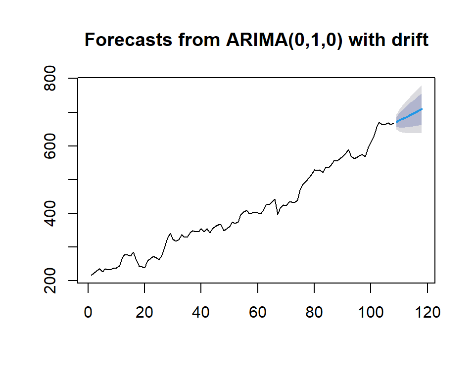

```r
fit <- Arima(female, order = c(0, 1, 0), include.drift = T)
plot(forecast(fit))
```

```r
summary(forecast(fit))
```

```
##
## Forecast method: ARIMA(0,1,0) with drift
##
## Model Information:
## Series: female
## ARIMA(0,1,0) with drift
##
## Coefficients:
##       drift
##       4.215
## s.e.  1.093
##
## sigma^2 estimated as 129:  log likelihood=-411.34
## AIC=826.68   AICc=826.8   BIC=832.03
##
## Error measures:
##                       ME     RMSE      MAE        MPE     MAPE      MASE
## Training set 0.001960972 11.25385 8.279046 -0.1344574 2.231458 0.9030153
##                    ACF1
## Training set 0.09833436
##
## Forecasts:
##     Point Forecast    Lo 80    Hi 80    Lo 95    Hi 95
## 109       671.2150 656.6571 685.7728 648.9507 693.4792
## 110       675.4299 654.8421 696.0178 643.9435 706.9163
## 111       679.6449 654.4300 704.8597 641.0820 718.2077
## 112       683.8598 654.7442 712.9754 639.3313 728.3883
## 113       688.0748 655.5225 720.6270 638.2904 737.8591
## 114       692.2897 656.6305 727.9489 637.7537 746.8258
## 115       696.5047 657.9883 735.0210 637.5990 755.4103
## 116       700.7196 659.5439 741.8953 637.7468 763.6924
## 117       704.9346 661.2611 748.6080 638.1418 771.7273
## 118       709.1495 663.1137 755.1854 638.7438 779.5553
```

# 13 SARIMA

## 13.1 Load data

```r
tour <- scan('data/timeseries/tourist.txt')
tour.ts <- ts(tour, start = 1981, frequency = 12)
```

## 13.2 time series plot

정상성 확인 2가지

- 등분산 확인
- 추세 확인

## 13.3 등분산 확인

- 분산 증가, 로그 변환 필요

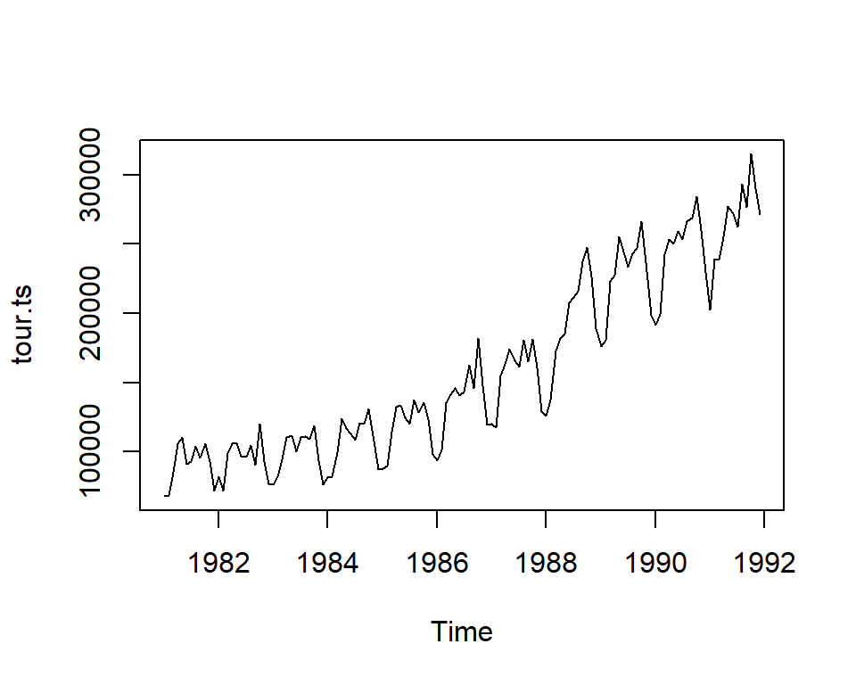

```r
plot(tour.ts)
```

**분산 안정화 변환**

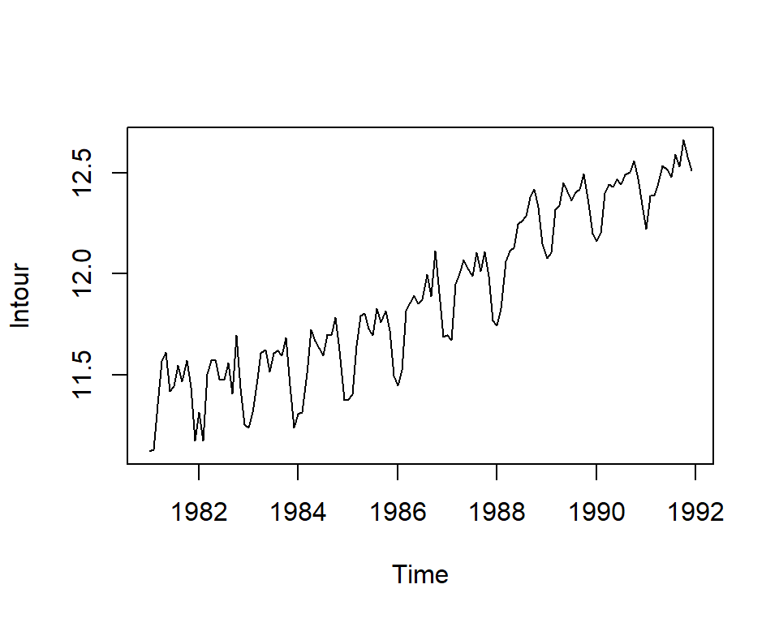

```r
lntour <- log(tour.ts)
plot(lntour)
```

## 13.4 추세 확인

일반 차분, 계절 차분 필요

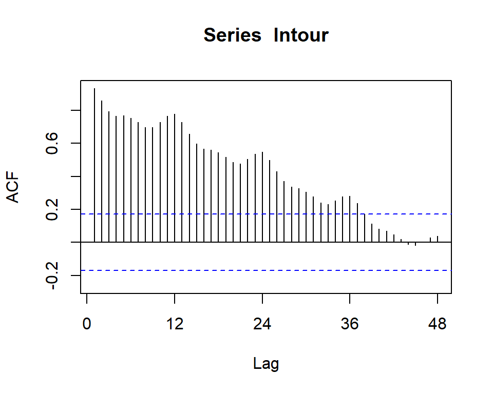

```r
Acf(lntour, lag.max = 48)
```

```r
ndiffs(lntour)
```

```
## [1] 1
```

```r
nsdiffs(lntour)
```

```
## [1] 1
```

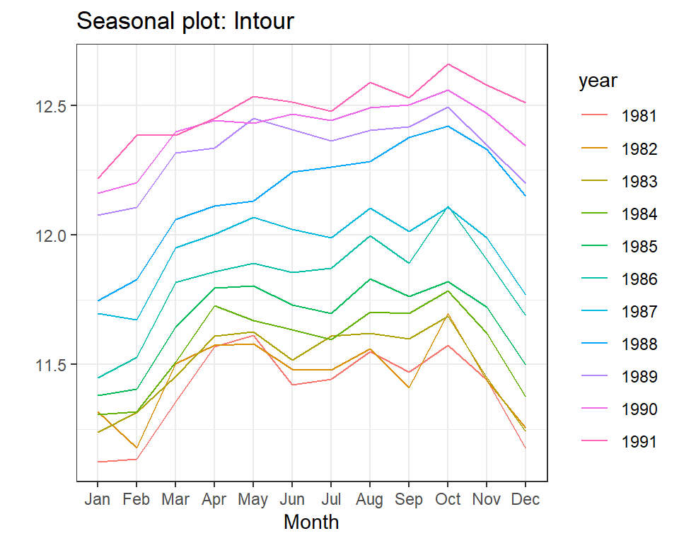

```r
ggseasonplot(lntour)
```

## 13.5 d = 1일 때 (일반 차분)

추가적으로 계절 차분 필요

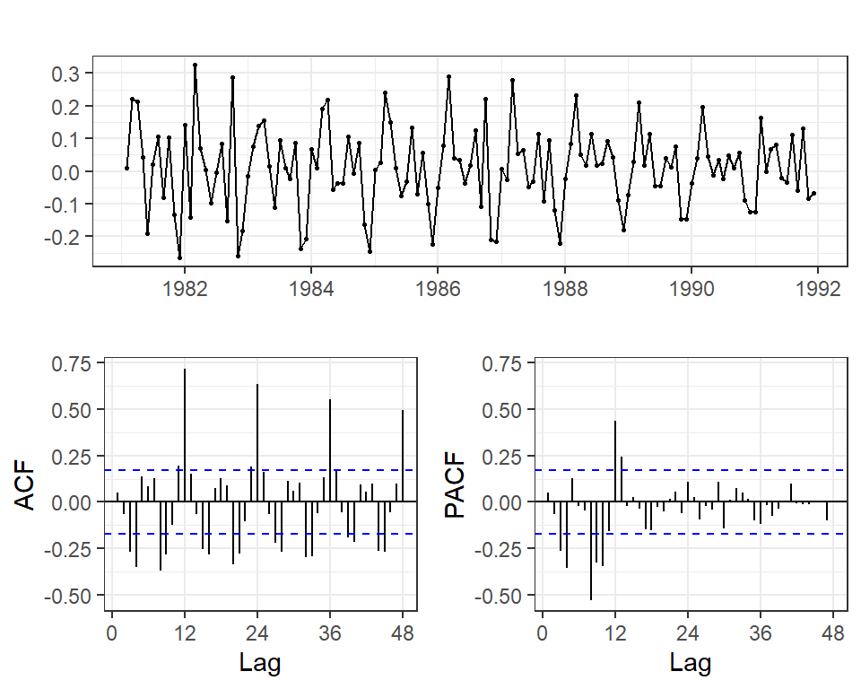

```r
tour_1 <- diff(lntour)
ggtsdisplay(tour_1, lag.max = 48)
```

## 13.6 D = 1일 때 (계절 차분)

추가적인 일반 차분이 필요해보임

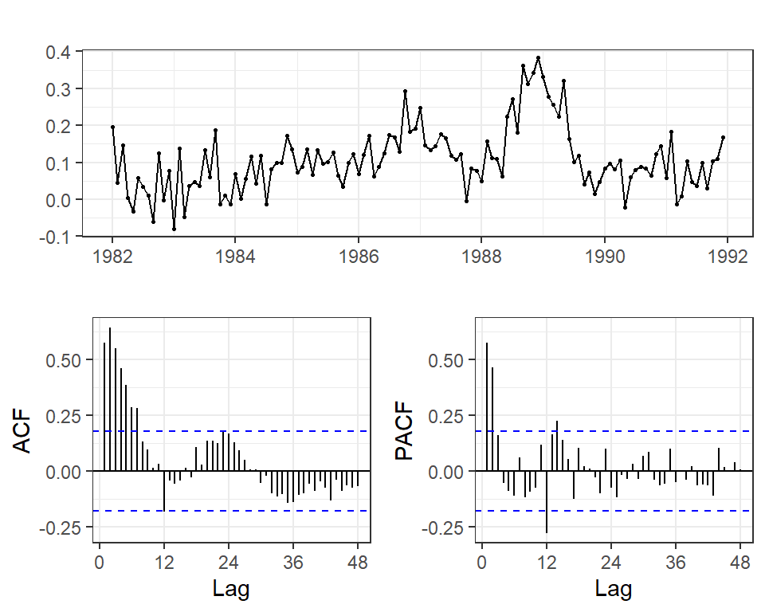

```r
tour_12 <- diff(lntour, lag = 12)
ggtsdisplay(tour_12, lag.max = 48)
```

```r
ndiffs(tour_12)
```

```
## [1] 1
```

## 13.7 d = 1, D = 1일 때

d = 1, D = 1로 결정

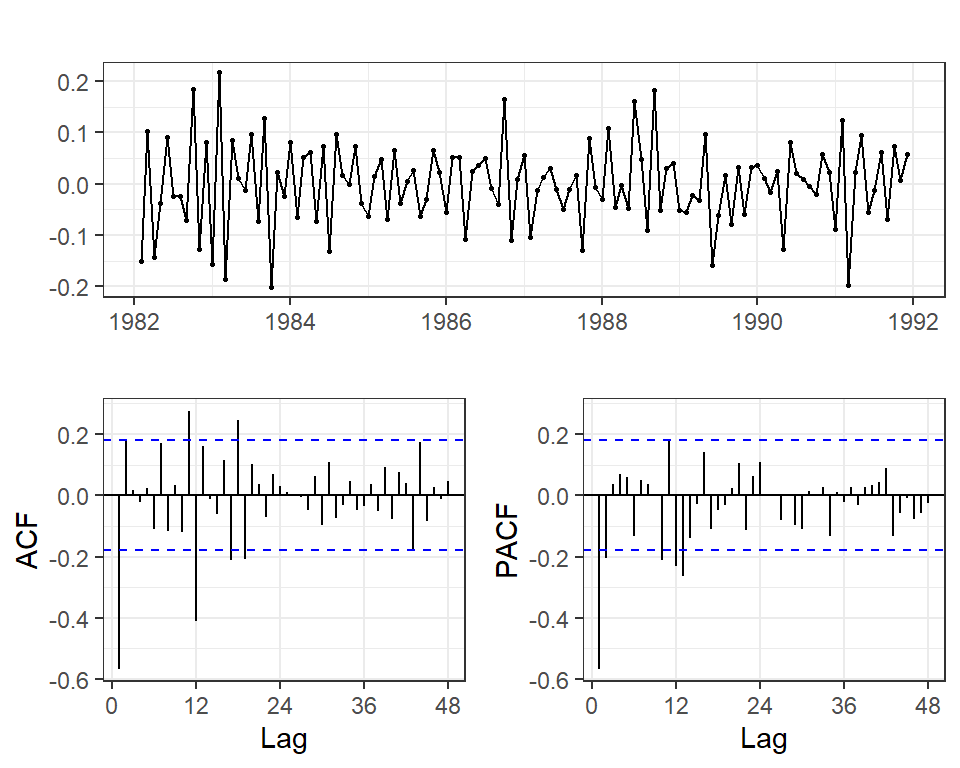

```r
tour_1_12 <- diff(tour_1, lag = 12)
ggtsdisplay(tour_1_12, lag.max = 48)
```